# Uncovering Winning Strategies in World-Class Women’s Singles Badminton

From the data I collected, I aimed to analyse the strategies in world-class women’s singles badminton, specifically how rally length, shot choice and shot placements contribute to winning points, and whether being the server affects the outcome. I’ve presented my findings using various graphs below to explore these aspects. By visualising this information, I hope to gain insights into shot effectiveness, tactical preferences, and evolving match trends that could inform successful playing strategies or training focus.

## Plot 1

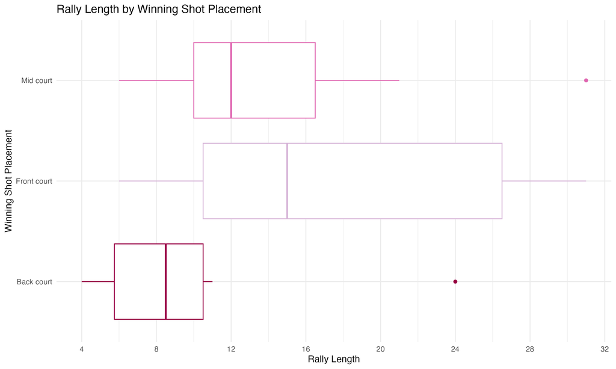

This horizontal boxplot shows the distribution of rally lengths, grouped by the placement of the winning shot (mid court, front court, back court). The graph was created to analyse where shots are placed to win points, and whether there is a relationship between shot placement and rally length.

The front court category has the widest box, indicating greater variability in rally lengths that end in this zone. It also has the highest median, which suggests that rallies ending in the front court tend to be longer. In contrast, the back court has the narrowest box and the lowest median, meaning rallies ending there are generally shorter and less variable. The mid court lies in between, with moderate rally lengths and variability.

This pattern may suggest that players are more likely to win points at the front of the court after extended rallies, possibly due to tactical net play or reduced energy levels, whereas rallies ending in the back court tend to be shorter, which may be the result of opponents misjudging whether a shot is going out.

There are also two noticeable outliers - a rally of 31 shots in the mid court and 24 in the back court. This shows that longer rallies can occasionally occur in areas typically associated with shorter exchanges. These outliers may be the result of strong defensive play by both players before a final winning shot.

## Plot 2

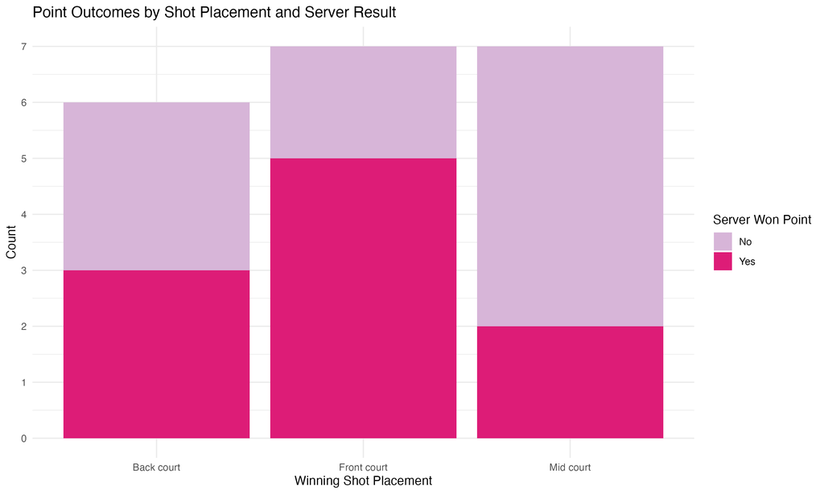

This bar chart compares the frequency of winning shots, grouped by shot placement, and colour-coded based on whether the server won the point. The total number of points won is similar across the three different shot placement categories (6 points won in the back court, 7 in the front court, and 7 in the mid court). The front court has the highest number of points won by the server. In the back court, there is a relatively balanced distribution between points won by the server and the receiver. The mid court shows fewer points won by the server, and more points won by the receiver.

This pattern may suggest that servers are more effective at finishing rallies at the net, while mid court exchanges may leave them more vulnerable to attacks.

## Plot 3

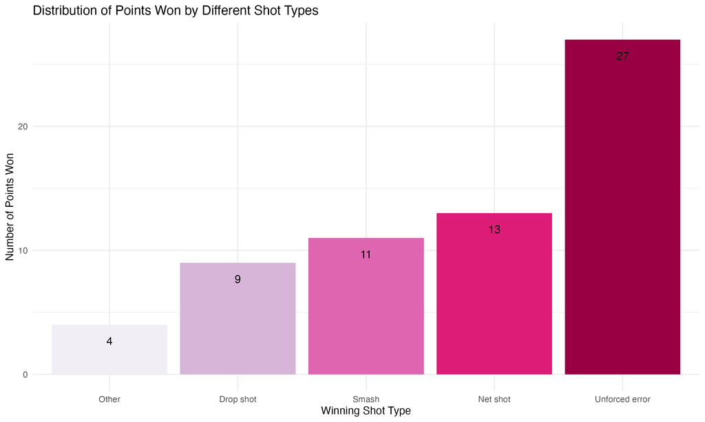

This bar chart shows the total number of points won by different shot types. Most of the observed rallies were won due to unforced errors (27 points), such as mishits or misjudged shots. The second most common shot to win points was the net shot (13 points), followed by smashes (11 points) and drop shots (9 points). The ‘Other’ category, which combines Clear and Lift shots, accounted for the fewest points, with a total of 4.

This suggests that many points were not won through a single attacking winner, such as a smash, but rather by forcing opponents into errors, possibly through sustained pressure or well-placed shots. Attacking shots, like net shots and smashes, also played a significant role, while clears and lifts were used less frequently to directly win points.

## Plot 4

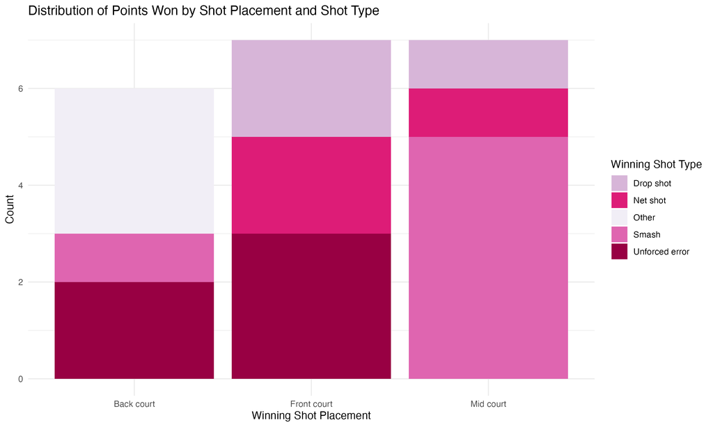

This bar chart shows the distribution of points won, grouped by the placement of the winning shot and colour-coded by shot type. From the graph, we can see which shot types are more commonly used to win points in different areas of the court. Points won in the front court were from drop shots, net shots or unforced errors. In the mid court, most points were won through smashes, along with some net kills or fast push shots from the net, as well as looser drop shots. Points won in the back court resulted from a mix of clears, lifts, smashes and unforced errors, likely caused by misjudging the back boundary line.

This pattern suggests that players often rely on precision and pressure at the net, power and speed in the mid court, and opponent errors or depth control in the back court. It reflects tactical variation in shot selection depending on the court position, and highlights how different areas have different winning opportunities.

## Plot 5

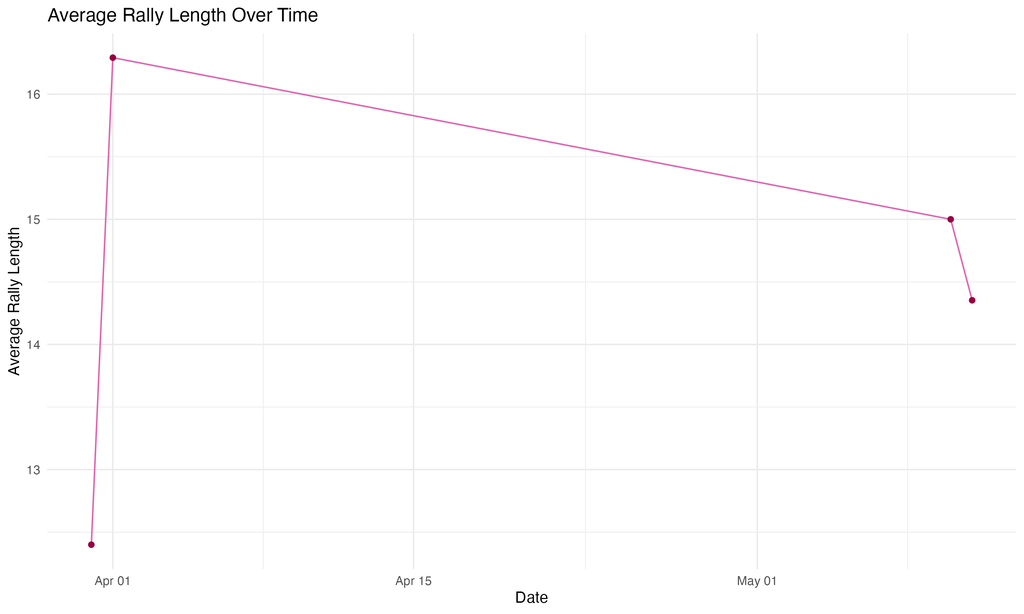

This line chart tracks the average rally length over time, based on observations made from YouTube match recordings. The trend shows how rally lengths varied across different matches in different tournaments, each featuring different players in the finals. This may reflect differences in playing styles, skill levels, strategies, or even fitness levels. For example, an increase in rally length on a specific day may suggest a match between players with similar styles or skill levels, leading to longer, more balanced rallies. In contrast, dips in the line could indicate more aggressive play or errors resulting in shorter rallies.

Since the data comes from video recordings, it’s important to note that these observations were not made during live matches, so external conditions like weather or temperature on the day a rally was observed are not factors in this analysis. However, because rallies from the same match were observed on the same day, the trend can still offer some insight into differences in play styles between players across various tournaments.

## Conclusion

The data reveals several key insights into the strategies used in elite women’s singles badminton. Rally length appears to be linked to the placement of the winning shot, with longer rallies often ending in the front court, possibly due to tactical net play or reduced energy levels. Shot placement also seems to be linked with whether the server wins the point - servers were more successful at finishing rallies in the front court, while mid court winners were more frequently played by the receiver. This suggests that certain zones may be advantageous depending on who is serving. In terms of shot types, unforced errors were the most common way rallies ended, highlighting the importance of consistency and keeping pressure on the opponent. Net shots and smashes were also effective, particularly in the front and mid court. Overall, these findings provide a clearer picture of tactical patterns in high-level women’s singles, and help identify which court zones and shot types I should focus on in training to improve my game.